# Examen_Final_DIP

### Dendograma

Nota: “Ocupa average linkeage”

```r
data_2014 <- filter(data_previo,year==2014)
```

*Data profiling data_2014

|  | uniques | nan | moda |
| --- | --- | --- | --- |
| year | 1 | 0 | 2014 |
| month | 12 | 0 | 3 |
| cbwd | 4 | 0 | SE |

|  | uniques | nan | minimo | maximo | promedio | desvest | mediana | moda | primer_cuartil | tercer_cuartil |
| --- | --- | --- | --- | --- | --- | --- | --- | --- | --- | --- |
| hour | 24 | 0 | 0.00 | 23.00 | 11.5028294 | 6.923706 | 11.00 | 13 | 6.00 | 18 |
| pm2.5 | 479 | 0 | 2.00 | 671.00 | 97.7485853 | 93.537763 | 72.00 | 9 | 28.00 | 133 |
| DEWP | 66 | 0 | -40.00 | 25.00 | 2.0740270 | 14.161110 | 4.00 | 18 | -9.00 | 15 |
| TEMP | 56 | 0 | -13.00 | 42.00 | 13.7095508 | 11.617501 | 15.00 | 20 | 3.00 | 23 |
| PRES | 47 | 0 | 993.00 | 1039.00 | 1016.6136967 | 9.757352 | 1016.00 | 1006 | 1008.00 | 1025 |
| Iws | 938 | 0 | 0.45 | 441.18 | 19.4695877 | 43.841381 | 4.91 | 0.89 | 1.79 | 17 |
| Is | 24 | 0 | 0.00 | 23.00 | 0.0342996 | 0.708886 | 0.00 | 0 | 0.00 | 0 |
| Ir | 23 | 0 | 0.00 | 23.00 | 0.1325788 | 1.034840 | 0.00 | 0 | 0.00 | 0 |

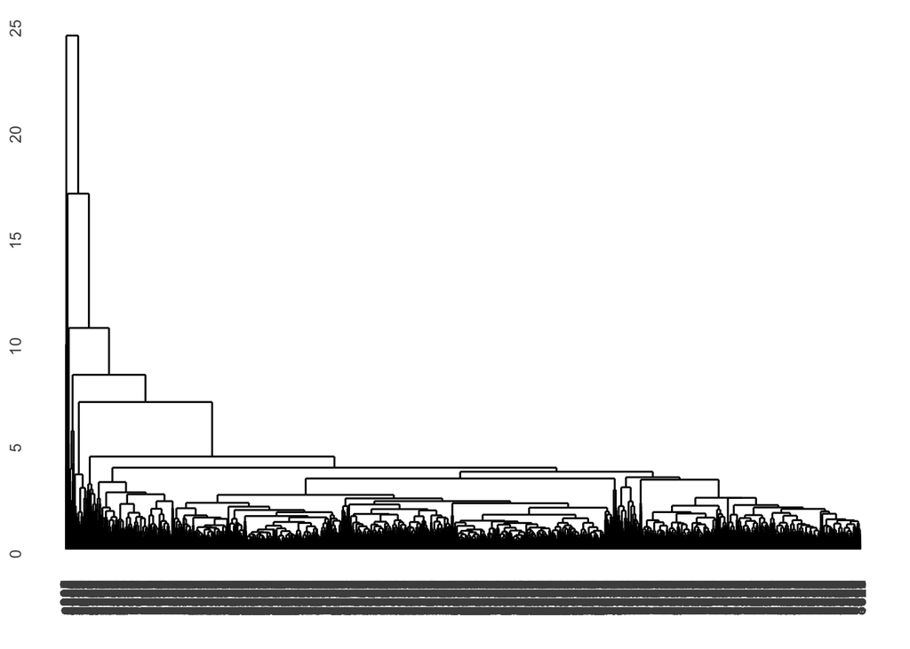

```r
##Usamos solo los datos del 2014 porque no funcionaba con todos los datos
data_2014_completo<-data_2014
data_2014 <- data_2014[,-c(1,2,8)]
data_2014_scaled <- scale(data_2014) %>% as.data.frame()

distance_matrix <- dist(data_2014_scaled)


dendogram_average <- hclust(distance_matrix,method="average")

ggdendrogram(dendogram_average, rotate=F, size =2)
```

Por nuestro gráfico de dendogramas, para tener menos de 10 grupos, utilizaremos un punto de corte de 7, debido a que vimos que esto es lo más eficiente para estos datos.

```
##
##    1    2    3    4    5    6    7    8    9   10
## 8428  145    7    5    3    5   48   13    3    2
```

```
##
##    1    2    3    4    5    6    7
## 8428  145    7    8    5   51   15
```

Realizamos 10 y 7 grupos para buscar continuar con la lógica de k-means, pero como vimos anteriormente es suficiente con 7 grupos para poder dividir los datos.

#### **Grupo 1**

```r
dp <- data_prof(filter(data_clusters,grupo == 1))
n1 <- nrow(filter(data_clusters,grupo == 1))
kable(dp$nums, format.args = list(big.mark=",", scientific=F), align = c(rep('c', 10)))
```

|  | Unicos | Uniqueness (%) | Vac??os | M??nimo | Máximo | Promedio | Mediana | Moda | 1er quartil | 3er quartil | D. E. |
| --- | --- | --- | --- | --- | --- | --- | --- | --- | --- | --- | --- |
| hour | 24 | 0.28 | 0 | 0.00 | 23.00 | 11.4752017 | 11.00 | 2 | 5.00 | 18.00 | 6.9384024 |
| pm2.5 | 479 | 5.68 | 0 | 2.00 | 671.00 | 99.4957285 | 74.00 | 11 | 30.00 | 135.00 | 94.0590285 |
| DEWP | 66 | 0.78 | 0 | -40.00 | 25.00 | 2.3223778 | 4.00 | 18 | -9.00 | 15.00 | 14.0466391 |
| TEMP | 56 | 0.66 | 0 | -13.00 | 42.00 | 13.8955861 | 15.00 | 20 | 4.00 | 23.00 | 11.6060494 |
| PRES | 47 | 0.56 | 0 | 993.00 | 1,039.00 | 1,016.4578785 | 1,016.00 | 1006 | 1,008.00 | 1,025.00 | 9.7215172 |
| Iws | 786 | 9.33 | 0 | 0.45 | 230.23 | 14.9448695 | 4.46 | 0.89 | 1.79 | 16.09 | 26.4904779 |
| Is | 4 | 0.05 | 0 | 0.00 | 3.00 | 0.0032036 | 0.00 | 0 | 0.00 | 0.00 | 0.0777284 |
| Ir | 8 | 0.09 | 0 | 0.00 | 7.00 | 0.0577836 | 0.00 | 0 | 0.00 | 0.00 | 0.4137857 |

```r
kable(dp$cats, format.args = list(big.mark=",", scientific=F), align = c(rep('c', 4)))
```

|  | Unicos | Uniqueness (%) | Vac??os | Moda |
| --- | --- | --- | --- | --- |
| year | 1 | 0.01 | 0 | 2014 |
| month | 12 | 0.14 | 0 | 3 |
| cbwd | 4 | 0.05 | 0 | SE |
| grupo | 1 | 0.01 | 0 | 1 |

#### **Grupo 2**

```r
dp <- data_prof(filter(data_clusters,grupo == 2))
n2 <- nrow(filter(data_clusters,grupo == 2))
kable(dp$nums, format.args = list(big.mark=",", scientific=F), align = c(rep('c', 10)))
```

|  | Unicos | Uniqueness (%) | Vac??os | M??nimo | Máximo | Promedio | Mediana | Moda | 1er quartil | 3er quartil | D. E. |
| --- | --- | --- | --- | --- | --- | --- | --- | --- | --- | --- | --- |
| hour | 24 | 16.55 | 0 | 0.00 | 23.00 | 13.786207 | 15.00 | 13 | 10.00 | 18.00 | 5.905725 |
| pm2.5 | 38 | 26.21 | 0 | 3.00 | 60.00 | 16.689655 | 11.00 | 9 | 9.00 | 16.00 | 14.221227 |
| DEWP | 26 | 17.93 | 0 | -27.00 | 2.00 | -17.048276 | -20.00 | -20 | -22.00 | -12.00 | 6.630455 |
| TEMP | 31 | 21.38 | 0 | -9.00 | 24.00 | 4.117241 | 0.00 | -3 | -3.00 | 13.00 | 9.188991 |
| PRES | 21 | 14.48 | 0 | 1,005.00 | 1,035.00 | 1,026.696552 | 1,030.00 | 1032 | 1,022.00 | 1,032.00 | 7.347830 |
| Iws | 140 | 96.55 | 0 | 156.45 | 441.18 | 279.803172 | 278.95 | 207.41 | 227.11 | 318.26 | 66.118881 |
| Is | 1 | 0.69 | 0 | 0.00 | 0.00 | 0.000000 | 0.00 | 0 | 0.00 | 0.00 | 0.000000 |
| Ir | 1 | 0.69 | 0 | 0.00 | 0.00 | 0.000000 | 0.00 | 0 | 0.00 | 0.00 | 0.000000 |

```r
kable(dp$cats, format.args = list(big.mark=",", scientific=F), align = c(rep('c', 4)))
```

|  | Unicos | Uniqueness (%) | Vac??os | Moda |
| --- | --- | --- | --- | --- |
| year | 1 | 0.69 | 0 | 2014 |
| month | 4 | 2.76 | 0 | 12 |
| cbwd | 1 | 0.69 | 0 | NW |
| grupo | 1 | 0.69 | 0 | 2 |

#### **Grupo 3**

```r
dp <- data_prof(filter(data_clusters,grupo == 3))
n3 <- nrow(filter(data_clusters,grupo == 3))
kable(dp$nums, format.args = list(big.mark=",", scientific=F), align = c(rep('c', 10)))
```

|  | Unicos | Uniqueness (%) | Vac??os | M??nimo | Máximo | Promedio | Mediana | Moda | 1er quartil | 3er quartil | D. E. |
| --- | --- | --- | --- | --- | --- | --- | --- | --- | --- | --- | --- |
| hour | 7 | 100.00 | 0 | 9.00 | 15.00 | 12.000000 | 12.00 | 9 | 10.500 | 13.500 | 2.1602469 |
| pm2.5 | 7 | 100.00 | 0 | 84.00 | 112.00 | 97.285714 | 94.00 | 84 | 89.500 | 106.000 | 10.6413390 |
| DEWP | 2 | 28.57 | 0 | -7.00 | -6.00 | -6.714286 | -7.00 | -7 | -7.000 | -6.500 | 0.4879500 |
| TEMP | 3 | 42.86 | 0 | -5.00 | -3.00 | -4.000000 | -4.00 | -4 | -4.500 | -3.500 | 0.8164966 |
| PRES | 4 | 57.14 | 0 | 1,025.00 | 1,029.00 | 1,027.428571 | 1,028.00 | 1029 | 1,026.000 | 1,029.000 | 1.7182494 |
| Iws | 7 | 100.00 | 0 | 33.98 | 46.06 | 39.732857 | 39.35 | 33.98 | 36.665 | 42.705 | 4.4020060 |
| Is | 7 | 100.00 | 0 | 4.00 | 10.00 | 7.000000 | 7.00 | 4 | 5.500 | 8.500 | 2.1602469 |
| Ir | 1 | 14.29 | 0 | 0.00 | 0.00 | 0.000000 | 0.00 | 0 | 0.000 | 0.000 | 0.0000000 |

```r
kable(dp$cats, format.args = list(big.mark=",", scientific=F), align = c(rep('c', 4)))
```

|  | Unicos | Uniqueness (%) | Vac??os | Moda |
| --- | --- | --- | --- | --- |
| year | 1 | 14.29 | 0 | 2014 |
| month | 1 | 14.29 | 0 | 2 |
| cbwd | 1 | 14.29 | 0 | SE |
| grupo | 1 | 14.29 | 0 | 3 |

#### **Grupo 4**

```r
dp <- data_prof(filter(data_clusters,grupo == 4))
n4 <- nrow(filter(data_clusters,grupo == 4))
kable(dp$nums, format.args = list(big.mark=",", scientific=F), align = c(rep('c', 10)))
```

|  | Unicos | Uniqueness (%) | Vac??os | M??nimo | Máximo | Promedio | Mediana | Moda | 1er quartil | 3er quartil | D. E. |
| --- | --- | --- | --- | --- | --- | --- | --- | --- | --- | --- | --- |
| hour | 8 | 100.0 | 0 | 16.00 | 23.00 | 19.5000 | 19.500 | 16 | 17.7500 | 21.2500 | 2.4494897 |
| pm2.5 | 6 | 75.0 | 0 | 98.00 | 109.00 | 105.5000 | 107.000 | 107 | 104.5000 | 108.2500 | 4.1747541 |
| DEWP | 2 | 25.0 | 0 | -7.00 | -6.00 | -6.5000 | -6.500 | -7 | -7.0000 | -6.0000 | 0.5345225 |
| TEMP | 2 | 25.0 | 0 | -4.00 | -3.00 | -3.3750 | -3.000 | -3 | -4.0000 | -3.0000 | 0.5175492 |
| PRES | 2 | 25.0 | 0 | 1,024.00 | 1,025.00 | 1,024.7500 | 1,025.000 | 1025 | 1,024.7500 | 1,025.0000 | 0.4629100 |
| Iws | 8 | 100.0 | 0 | 47.85 | 63.06 | 55.6225 | 56.125 | 47.85 | 50.9825 | 59.9275 | 5.6223222 |
| Is | 8 | 100.0 | 0 | 11.00 | 18.00 | 14.5000 | 14.500 | 11 | 12.7500 | 16.2500 | 2.4494897 |
| Ir | 1 | 12.5 | 0 | 0.00 | 0.00 | 0.0000 | 0.000 | 0 | 0.0000 | 0.0000 | 0.0000000 |

```r
kable(dp$cats, format.args = list(big.mark=",", scientific=F), align = c(rep('c', 4)))
```

|  | Unicos | Uniqueness (%) | Vac??os | Moda |
| --- | --- | --- | --- | --- |
| year | 1 | 12.5 | 0 | 2014 |
| month | 1 | 12.5 | 0 | 2 |
| cbwd | 1 | 12.5 | 0 | SE |
| grupo | 1 | 12.5 | 0 | 4 |

#### **Grupo 5**

```r
dp <- data_prof(filter(data_clusters,grupo == 5))
n5 <- nrow(filter(data_clusters,grupo == 5))
kable(dp$nums, format.args = list(big.mark=",", scientific=F), align = c(rep('c', 10)))
```

|  | Unicos | Uniqueness (%) | Vac??os | M??nimo | Máximo | Promedio | Mediana | Moda | 1er quartil | 3er quartil | D. E. |
| --- | --- | --- | --- | --- | --- | --- | --- | --- | --- | --- | --- |
| hour | 5 | 100 | 0 | 0.00 | 4 | 2.000 | 2.00 | 0 | 1.00 | 3.00 | 1.5811388 |
| pm2.5 | 5 | 100 | 0 | 88.00 | 115 | 99.600 | 95.00 | 88 | 94.00 | 106.00 | 10.7842478 |
| DEWP | 2 | 40 | 0 | -7.00 | -6 | -6.200 | -6.00 | -6 | -6.00 | -6.00 | 0.4472136 |
| TEMP | 1 | 20 | 0 | -4.00 | -4 | -4.000 | -4.00 | -4 | -4.00 | -4.00 | 0.0000000 |
| PRES | 2 | 40 | 0 | 1,024.00 | 1,025 | 1,024.800 | 1,025.00 | 1025 | 1,025.00 | 1,025.00 | 0.4472136 |
| Iws | 5 | 100 | 0 | 0.89 | 72 | 55.902 | 69.32 | 0.89 | 66.19 | 71.11 | 30.8327532 |
| Is | 5 | 100 | 0 | 19.00 | 23 | 21.000 | 21.00 | 19 | 20.00 | 22.00 | 1.5811388 |
| Ir | 1 | 20 | 0 | 0.00 | 0 | 0.000 | 0.00 | 0 | 0.00 | 0.00 | 0.0000000 |

```r
kable(dp$cats, format.args = list(big.mark=",", scientific=F), align = c(rep('c', 4)))
```

|  | Unicos | Uniqueness (%) | Vac??os | Moda |
| --- | --- | --- | --- | --- |
| year | 1 | 20 | 0 | 2014 |
| month | 1 | 20 | 0 | 2 |
| cbwd | 2 | 40 | 0 | SE |
| grupo | 1 | 20 | 0 | 5 |

#### **Grupo 6**

```r
dp <- data_prof(filter(data_clusters,grupo == 6))
n6 <- nrow(filter(data_clusters,grupo == 6))
kable(dp$nums, format.args = list(big.mark=",", scientific=F), align = c(rep('c', 10)))
```

|  | Unicos | Uniqueness (%) | Vac??os | M??nimo | Máximo | Promedio | Mediana | Moda | 1er quartil | 3er quartil | D. E. |
| --- | --- | --- | --- | --- | --- | --- | --- | --- | --- | --- | --- |
| hour | 20 | 39.22 | 0 | 0.00 | 23.00 | 8.215686 | 7.00 | 4 | 4.00 | 10.00 | 5.794182 |
| pm2.5 | 38 | 74.51 | 0 | 17.00 | 116.00 | 57.529412 | 53.00 | 21 | 34.50 | 81.00 | 26.823387 |
| DEWP | 15 | 29.41 | 0 | 7.00 | 23.00 | 15.274510 | 17.00 | 18 | 10.00 | 18.00 | 4.547872 |
| TEMP | 12 | 23.53 | 0 | 10.00 | 24.00 | 16.490196 | 18.00 | 11 | 11.00 | 20.00 | 4.397147 |
| PRES | 16 | 31.37 | 0 | 1,003.00 | 1,019.00 | 1,011.490196 | 1,010.00 | 1009 | 1,008.00 | 1,016.50 | 4.912729 |
| Iws | 29 | 56.86 | 0 | 0.89 | 166.73 | 18.372549 | 7.16 | 1.79 | 3.13 | 15.65 | 37.731041 |
| Is | 1 | 1.96 | 0 | 0.00 | 0.00 | 0.000000 | 0.00 | 0 | 0.00 | 0.00 | 0.000000 |
| Ir | 10 | 19.61 | 0 | 3.00 | 13.00 | 7.901961 | 7.00 | 6 | 6.00 | 9.00 | 2.042106 |

```r
kable(dp$cats, format.args = list(big.mark=",", scientific=F), align = c(rep('c', 4)))
```

|  | Unicos | Uniqueness (%) | Vac??os | Moda |
| --- | --- | --- | --- | --- |
| year | 1 | 1.96 | 0 | 2014 |
| month | 7 | 13.73 | 0 | 9 |
| cbwd | 4 | 7.84 | 0 | NW |
| grupo | 1 | 1.96 | 0 | 6 |

#### **Grupo 7**

```r
dp <- data_prof(filter(data_clusters,grupo == 7))
n7 <- nrow(filter(data_clusters,grupo == 7))
kable(dp$nums, format.args = list(big.mark=",", scientific=F), align = c(rep('c', 10)))
```

|  | Unicos | Uniqueness (%) | Vac??os | M??nimo | Máximo | Promedio | Mediana | Moda | 1er quartil | 3er quartil | D. E. |
| --- | --- | --- | --- | --- | --- | --- | --- | --- | --- | --- | --- |
| hour | 10 | 66.67 | 0 | 11.00 | 21.00 | 14.80000 | 14.00 | 11 | 12.50 | 16.5 | 3.098387 |
| pm2.5 | 14 | 93.33 | 0 | 8.00 | 75.00 | 31.86667 | 27.00 | 22 | 21.50 | 39.0 | 17.137539 |
| DEWP | 3 | 20.00 | 0 | 10.00 | 17.00 | 13.93333 | 16.00 | 10 | 10.00 | 17.0 | 3.348063 |
| TEMP | 5 | 33.33 | 0 | 12.00 | 18.00 | 15.73333 | 17.00 | 18 | 13.00 | 18.0 | 2.658320 |
| PRES | 9 | 60.00 | 0 | 1,002.00 | 1,018.00 | 1,012.00000 | 1,016.00 | 1016 | 1,005.50 | 1,017.0 | 6.469710 |
| Iws | 12 | 80.00 | 0 | 0.89 | 26.83 | 8.04800 | 4.02 | 0.89 | 1.79 | 12.3 | 8.850493 |
| Is | 1 | 6.67 | 0 | 0.00 | 0.00 | 0.00000 | 0.00 | 0 | 0.00 | 0.0 | 0.000000 |
| Ir | 10 | 66.67 | 0 | 13.00 | 23.00 | 17.20000 | 17.00 | 14 | 15.00 | 19.0 | 2.956832 |

```r
kable(dp$cats, format.args = list(big.mark=",", scientific=F), align = c(rep('c', 4)))
```

|  | Unicos | Uniqueness (%) | Vac??os | Moda |
| --- | --- | --- | --- | --- |
| year | 1 | 6.67 | 0 | 2014 |
| month | 2 | 13.33 | 0 | 9 |
| cbwd | 4 | 26.67 | 0 | NW |
| grupo | 1 | 6.67 | 0 | 7 |